# Study 1, Exploratory

Mousetracker analysis script

ANON

2021-04-08

# Data preparation

## Load data

```r
Main <- read_rds("data/Study1.rds")
Demos <- read_csv("data/Demos.csv")
All <- merge(Main, Demos, by.x='subject', by.y='subject')

#this is the question in which people say whether they want their data included in the study.
Test <-  subset(All, Q47==1)
```

## Create race and sex variables for stimuli

```r
Test$race <- ifelse(startsWith(Test$code, "b"), "B",
                    ifelse(startsWith(Test$code, "a"), "A", "W"))
table(Test$race)
```

```
##
##     A     B     W
## 21304 21344 21221
```

```r
Test$sex <- ifelse(endsWith(Test$code, "f"), "F", "M")
table(Test$sex)
```

```
##
##     F     M
## 31922 31947
```

## AUC variable creation

The dataset has a weird format in which there is no overall AUC scores, but instead one for each response choice, with the other taking the value “NA”. Convert NAs to 0s for the purposes of combining into a single “AUC” variable.

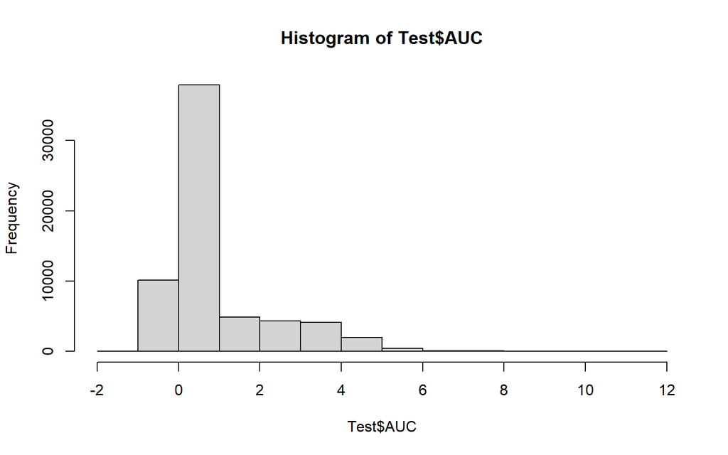

```r
Test$AUC_1[is.na(Test$AUC_1)] <- 0
Test$AUC_2[is.na(Test$AUC_2)] <- 0

Test$AUC <- Test$AUC_1 + Test$AUC_2
#just checking the distribution to make sure adding didn't do anything weird
hist(Test$AUC)
```

## Trait variable creation

Create a “trait” variable indicating which trait was rated (between-subjects). Check for approximately equal counts.

```r
Test$resp_1 <- as.character(Test$resp_1)

Test$trait <- ifelse(endsWith(Test$resp_1, "STRONG "), "Str",
                     ifelse(endsWith(Test$resp_1, "TRUSTWORTHY"), "Tru",
                            ifelse(endsWith(Test$resp_1, "DOMINANT"), "Dom",
                                   ifelse(endsWith(Test$resp_1, "ATTRACTIVE"), "Att",
                                          ifelse(endsWith(Test$resp_1, "FRIENDLY "), "Fri", "Int")))))

table(Test$trait)
```

```
##
##   Att   Dom   Fri   Int   Str   Tru
## 12855 10247 10920 11179 11990  6678
```

## Response recoding

Recode the response variable such that -1 equals “less” and 1 equals “more”. Check whether numeric, see counts as descriptives.

```r
Test$response_c <- ifelse(Test$response==2, 1, -1)
is.numeric(Test$response_c)
```

```
## [1] TRUE
```

```r
table(Test$response_c)
```

```
##
##    -1     1
## 35529 28340
```

## Creating the congruence variable

Code “congruence” as a function of trait. BM, BF, AM, AF, WM, WF questions at the perceiver level. These items are Stereotype Knowledge items on a 7-point scale from “Not at all” to “Very much”.

Subset data by race and sex, code congruence, then rebind. Not the most parsimonious code but functions properly.

```r
TestBM <- subset(Test, Test$sex=="M" & Test$race=="B")

  TestBM$congruence <- ifelse(TestBM$trait=="Att", TestBM$BM_1,
                            ifelse(TestBM$trait=="Dom",  TestBM$BM_2,
                                   ifelse(TestBM$trait=="Fri", TestBM$BM_3,
                                          ifelse(TestBM$trait=="Int", TestBM$BM_4,
                                                 ifelse(TestBM$trait=="Str", TestBM$BM_5, TestBM$BM_6)))))

TestAM <- subset(Test, Test$sex=="M" & Test$race=="A")

TestAM$congruence <- ifelse(TestAM$trait=="Att", TestAM$AM_1,
                              ifelse(TestAM$trait=="Dom",  TestAM$AM_2,
                                     ifelse(TestAM$trait=="Fri", TestAM$AM_3,
                                            ifelse(TestAM$trait=="Int", TestAM$AM_4,
                                                   ifelse(TestAM$trait=="Str", TestAM$AM_5, TestAM$AM_6)))))

TestWM <- subset(Test, Test$sex=="M" & Test$race=="W")

TestWM$congruence <- ifelse(TestWM$trait=="Att", TestWM$WM_1,
                            ifelse(TestWM$trait=="Dom",  TestWM$WM_2,
                                   ifelse(TestWM$trait=="Fri", TestWM$WM_3,
                                          ifelse(TestWM$trait=="Int", TestWM$WM_4,
                                                 ifelse(TestWM$trait=="Str", TestWM$WM_5, TestWM$WM_6)))))

TestBF <- subset(Test, Test$sex=="F" & Test$race=="B")

TestBF$congruence <- ifelse(TestBF$trait=="Att", TestBF$BF_1,
                            ifelse(TestBF$trait=="Dom",  TestBF$BF_2,
                                   ifelse(TestBF$trait=="Fri", TestBF$BF_3,
                                          ifelse(TestBF$trait=="Int", TestBF$BF_4,
                                                 ifelse(TestBF$trait=="Str", TestBF$BF_5, TestBF$BF_6)))))

TestAF <- subset(Test, Test$sex=="F" & Test$race=="A")

TestAF$congruence <- ifelse(TestAF$trait=="Att", TestAF$AF_1,
                            ifelse(TestAF$trait=="Dom",  TestAF$AF_2,
                                   ifelse(TestAF$trait=="Fri", TestAF$AF_3,
                                          ifelse(TestAF$trait=="Int", TestAF$AF_4,
                                                 ifelse(TestAF$trait=="Str", TestAF$AF_5, TestAF$AF_6)))))

TestWF <- subset(Test, Test$sex=="F" & Test$race=="W")

TestWF$congruence <- ifelse(TestWF$trait=="Att", TestWF$WF_1,
                            ifelse(TestWF$trait=="Dom",  TestWF$WF_2,
                                   ifelse(TestWF$trait=="Fri", TestWF$WF_3,
                                          ifelse(TestWF$trait=="Int", TestWF$WF_4,
                                                 ifelse(TestWF$trait=="Str", TestWF$WF_5, TestWF$WF_6)))))

Test <- rbind(TestBM, TestAM, TestWM, TestBF, TestAF, TestWF)
```

This is a check for congruence to make sure that the create values make sense. Fit linear models for stereotype knowledge using “congruence” on each subset of traits, checks for expected patterns.

```r
Check <- data.frame(aggregate(congruence ~ subject*race*sex*trait, data=Test, mean, na.rm=TRUE))

AttSK <- lm(congruence ~ race*sex, data=subset(Check, trait=="Att"))
anova(AttSK)
```

```
## Analysis of Variance Table
##
## Response: congruence
##            Df Sum Sq Mean Sq F value    Pr(>F)
## race        2 180.48  90.242 66.3578 < 2.2e-16 ***
## sex         1  24.24  24.242 17.8261 3.357e-05 ***
## race:sex    2  22.39  11.197  8.2334 0.0003418 ***
## Residuals 258 350.86   1.360
## ---
## Signif. codes:  0 '***' 0.001 '**' 0.01 '*' 0.05 '.' 0.1 ' ' 1
```

```r
summ(AttSK)
```

```
## MODEL INFO:
## Observations: 264
## Dependent Variable: congruence
## Type: OLS linear regression
##
## MODEL FIT:
## F(5,258) = 33.40, p = 0.00
## R² = 0.39
## Adj. R² = 0.38
##
## Standard errors: OLS
## ------------------------------------------------
##                      Est.   S.E.   t val.      p
## ----------------- ------- ------ -------- ------
## (Intercept)          5.05   0.18    28.70   0.00
## raceB               -0.55   0.25    -2.19   0.03
## raceW                1.30   0.25     5.21   0.00
## sexM                -1.41   0.25    -5.67   0.00
## raceB:sexM           1.36   0.35     3.88   0.00
## raceW:sexM           1.05   0.35     2.97   0.00
## ------------------------------------------------
```

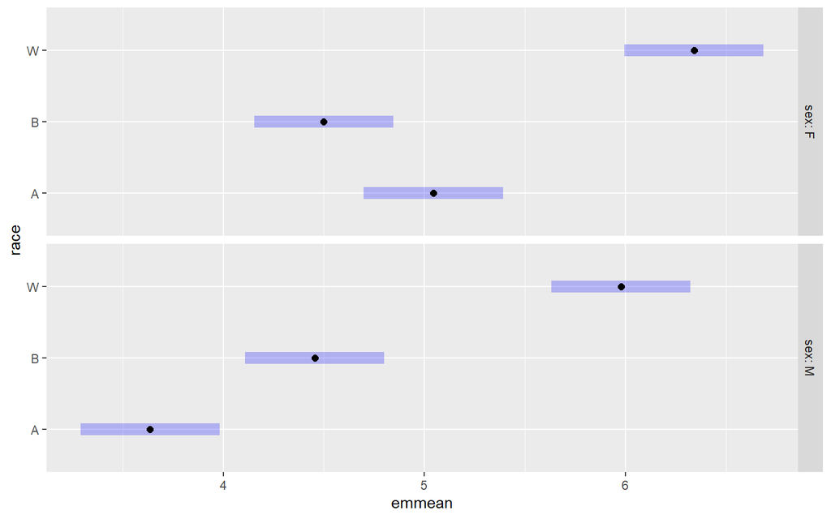

```r
AttSK_EM <- emmeans(AttSK, ~ race | sex)
plot(AttSK_EM)
```

```r
DomSK <- lm(congruence ~ race*sex, data=subset(Check, trait=="Dom"))
anova(DomSK)
```

```
## Analysis of Variance Table
##
## Response: congruence
##            Df  Sum Sq Mean Sq F value    Pr(>F)
## race        2 206.954 103.477 72.6153 < 2.2e-16 ***
## sex         1  77.042  77.042 54.0643 4.272e-12 ***
## race:sex    2  20.194  10.097  7.0858  0.001052 **
## Residuals 210 299.250   1.425
## ---
## Signif. codes:  0 '***' 0.001 '**' 0.01 '*' 0.05 '.' 0.1 ' ' 1
```

```r
summ(DomSK)
```

```
## MODEL INFO:
## Observations: 216
## Dependent Variable: congruence
## Type: OLS linear regression
##
## MODEL FIT:
## F(5,210) = 42.69, p = 0.00
## R² = 0.50
## Adj. R² = 0.49
##
## Standard errors: OLS
## -----------------------------------------------
##                     Est.   S.E.   t val.      p
## ----------------- ------ ------ -------- ------
## (Intercept)         2.89   0.20    14.52   0.00
## raceB               2.28   0.28     8.10   0.00
## raceW               0.92   0.28     3.26   0.00
## sexM                0.69   0.28     2.47   0.01
## raceB:sexM          0.14   0.40     0.35   0.73
## raceW:sexM          1.36   0.40     3.42   0.00
## -----------------------------------------------
```

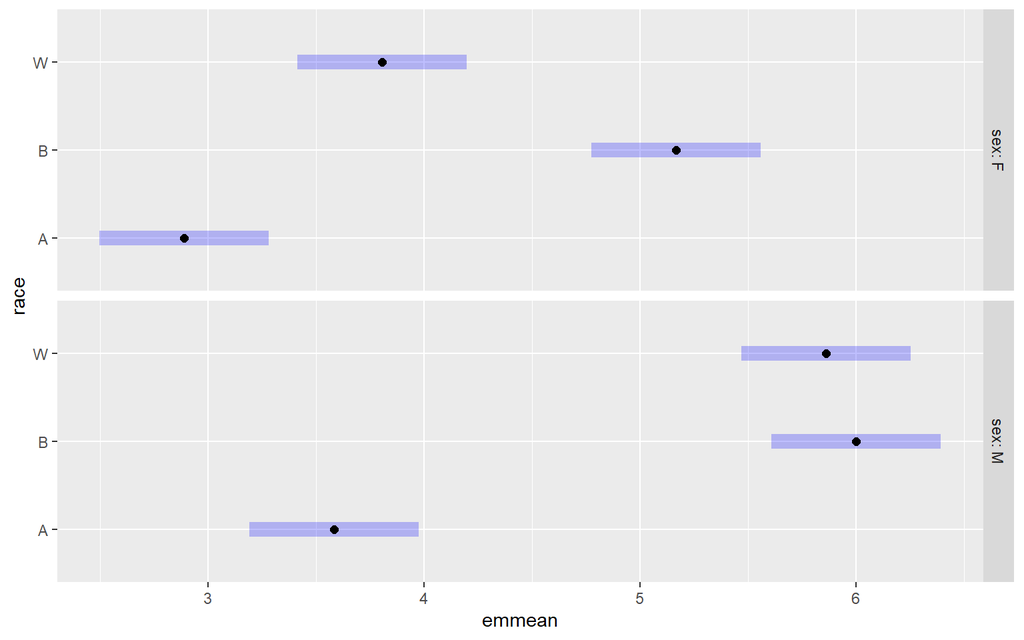

```r
DomSK_EM <- emmeans(DomSK, ~ race | sex)
plot(DomSK_EM)
```

```r
FriSK <- lm(congruence ~ race*sex, data=subset(Check, trait=="Fri"))
anova(FriSK)
```

```
## Analysis of Variance Table
##
## Response: congruence
##            Df Sum Sq Mean Sq F value    Pr(>F)
## race        2  75.64  37.820 21.4114 3.142e-09 ***
## sex         1   2.74   2.741  1.5519    0.2142
## race:sex    2   0.80   0.399  0.2260    0.7979
## Residuals 222 392.13   1.766
## ---
## Signif. codes:  0 '***' 0.001 '**' 0.01 '*' 0.05 '.' 0.1 ' ' 1
```

```r
summ(FriSK)
```

```
## MODEL INFO:
## Observations: 228
## Dependent Variable: congruence
## Type: OLS linear regression
##
## MODEL FIT:
## F(5,222) = 8.97, p = 0.00
## R² = 0.17
## Adj. R² = 0.15
##
## Standard errors: OLS
## ------------------------------------------------
##                      Est.   S.E.   t val.      p
## ----------------- ------- ------ -------- ------
## (Intercept)          4.79   0.22    22.21   0.00
## raceB               -0.74   0.30    -2.42   0.02
## raceW                0.58   0.30     1.90   0.06
## sexM                -0.08   0.30    -0.26   0.80
## raceB:sexM          -0.29   0.43    -0.67   0.50
## raceW:sexM          -0.13   0.43    -0.31   0.76
## ------------------------------------------------
```

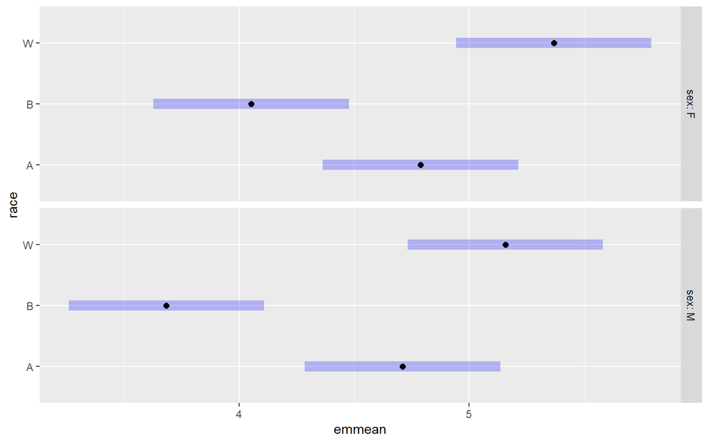

```r
FriSK_EM <- emmeans(FriSK, ~ race | sex)
plot(FriSK_EM)
```

```r
IntSK <- lm(congruence ~ race*sex, data=subset(Check, trait=="Int"))
anova(IntSK)
```

```
## Analysis of Variance Table
##
## Response: congruence
##            Df  Sum Sq Mean Sq F value  Pr(>F)
## race        2 231.600 115.800 99.6404 < 2e-16 ***
## sex         1   3.267   3.267  2.8108 0.09497 .
## race:sex    2   7.033   3.517  3.0259 0.05042 .
## Residuals 234 271.950   1.162
## ---
## Signif. codes:  0 '***' 0.001 '**' 0.01 '*' 0.05 '.' 0.1 ' ' 1
```

```r
summ(IntSK)
```

```
## MODEL INFO:
## Observations: 240
## Dependent Variable: congruence
## Type: OLS linear regression
##
## MODEL FIT:
## F(5,234) = 41.63, p = 0.00
## R² = 0.47
## Adj. R² = 0.46
##
## Standard errors: OLS
## ------------------------------------------------
##                      Est.   S.E.   t val.      p
## ----------------- ------- ------ -------- ------
## (Intercept)          5.95   0.17    34.91   0.00
## raceB               -2.05   0.24    -8.50   0.00
## raceW               -1.07   0.24    -4.46   0.00
## sexM                 0.45   0.24     1.87   0.06
## raceB:sexM          -0.70   0.34    -2.05   0.04
## raceW:sexM           0.05   0.34     0.15   0.88
## ------------------------------------------------
```

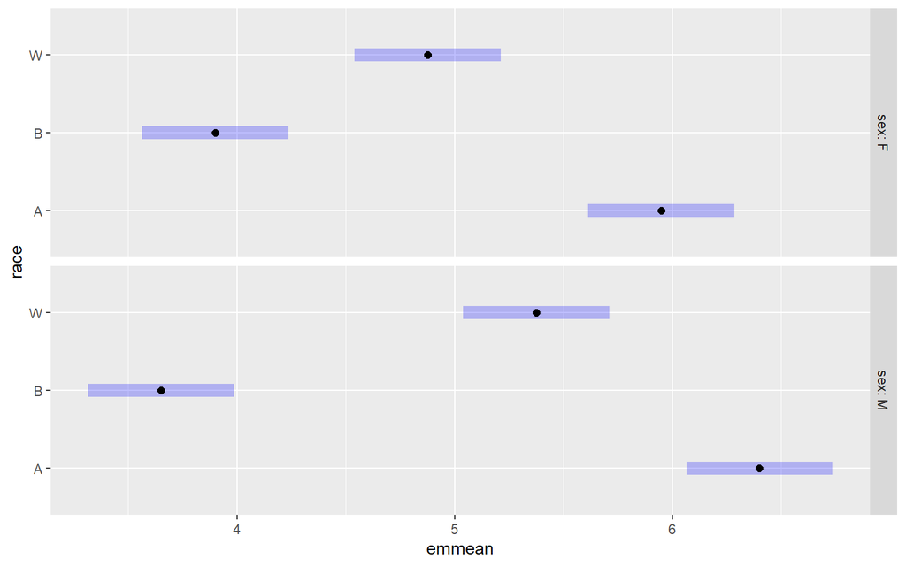

```r
IntSK_EM <- emmeans(IntSK, ~ race | sex)
plot(IntSK_EM)
```

```r
StrSK <- lm(congruence ~ race*sex, data=subset(Check, trait=="Str"))
anova(StrSK)
```

```
## Analysis of Variance Table
##
## Response: congruence
##            Df Sum Sq Mean Sq  F value    Pr(>F)
## race        2 376.26 188.129 176.2828 < 2.2e-16 ***
## sex         1 110.70 110.704 103.7332 < 2.2e-16 ***
## race:sex    2  11.81   5.904   5.5324  0.004492 **
## Residuals 234 249.72   1.067
## ---
## Signif. codes:  0 '***' 0.001 '**' 0.01 '*' 0.05 '.' 0.1 ' ' 1
```

```r
summ(StrSK)
```

```
## MODEL INFO:
## Observations: 240
## Dependent Variable: congruence
## Type: OLS linear regression
##
## MODEL FIT:
## F(5,234) = 93.47, p = 0.00
## R² = 0.67
## Adj. R² = 0.66
##
## Standard errors: OLS
## -----------------------------------------------
##                     Est.   S.E.   t val.      p
## ----------------- ------ ------ -------- ------
## (Intercept)         2.38   0.16    14.54   0.00
## raceB               2.72   0.23    11.80   0.00
## raceW               0.85   0.23     3.68   0.00
## sexM                0.77   0.23     3.36   0.00
## raceB:sexM          0.68   0.33     2.07   0.04
## raceW:sexM          1.08   0.33     3.29   0.00
## -----------------------------------------------
```

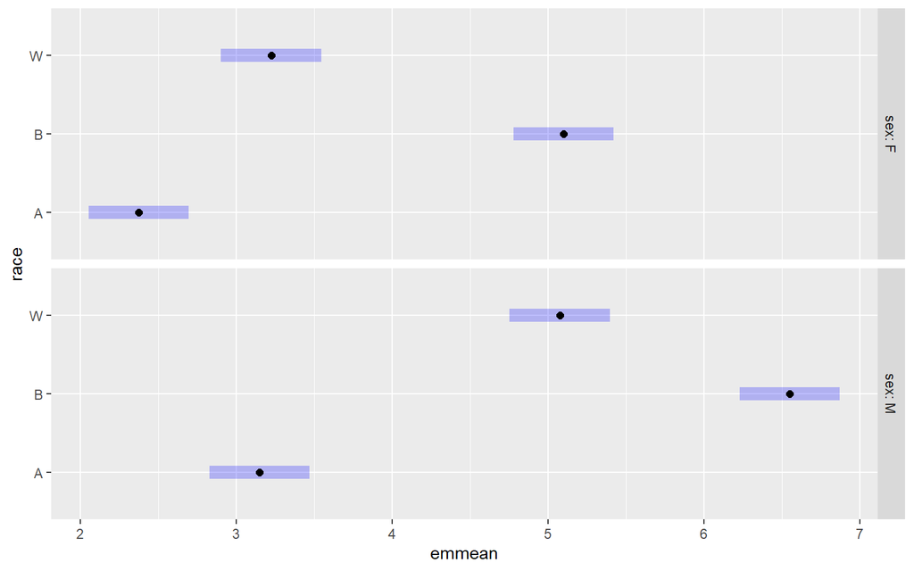

```r
StrSK_EM <- emmeans(StrSK, ~ race | sex)
plot(StrSK_EM)
```

```r
TruSK <- lm(congruence ~ race*sex, data=subset(Check, trait=="Tru"))
anova(TruSK)
```

```
## Analysis of Variance Table
##
## Response: congruence
##            Df  Sum Sq Mean Sq F value    Pr(>F)
## race        2  67.931  33.965 25.5957 3.511e-10 ***
## sex         1  14.062  14.062 10.5973  0.001425 **
## race:sex    2   2.042   1.021  0.7693  0.465322
## Residuals 138 183.125   1.327
## ---
## Signif. codes:  0 '***' 0.001 '**' 0.01 '*' 0.05 '.' 0.1 ' ' 1
```

```r
summ(TruSK)
```

```
## MODEL INFO:
## Observations: 144
## Dependent Variable: congruence
## Type: OLS linear regression
##
## MODEL FIT:
## F(5,138) = 12.67, p = 0.00
## R² = 0.31
## Adj. R² = 0.29
##
## Standard errors: OLS
## ------------------------------------------------
##                      Est.   S.E.   t val.      p
## ----------------- ------- ------ -------- ------
## (Intercept)          5.17   0.24    21.97   0.00
## raceB               -0.83   0.33    -2.51   0.01
## raceW                0.67   0.33     2.00   0.05
## sexM                -0.33   0.33    -1.00   0.32
## raceB:sexM          -0.58   0.47    -1.24   0.22
## raceW:sexM          -0.29   0.47    -0.62   0.54
## ------------------------------------------------
```

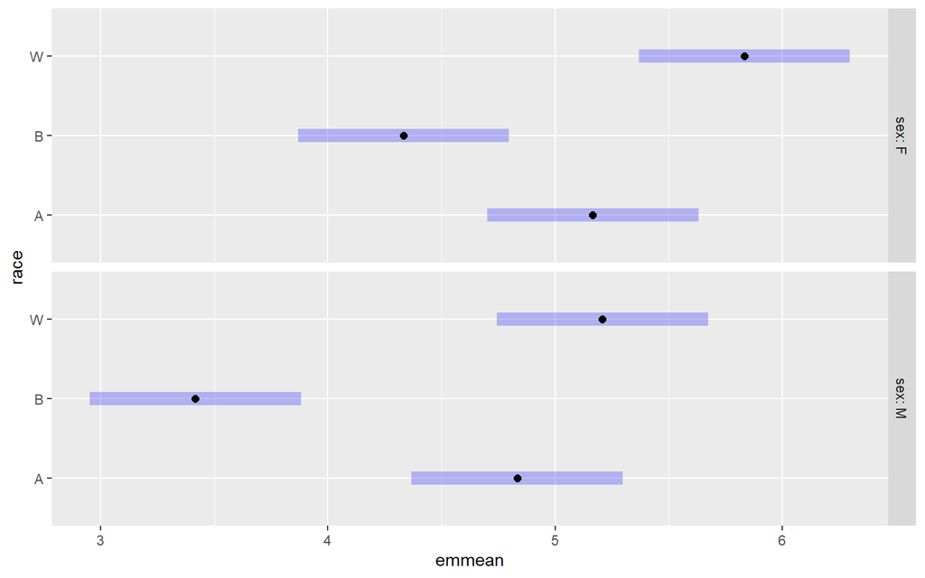

```r
TruSK_EM <- emmeans(TruSK, ~ race | sex)
plot(TruSK_EM)
```

# Prediction and details on centering and modeling

For the main analysis, we expect a negative interaction. As stereotype congruence increases (e.g., participant thinks Black men are dominant), then AUC for the “more” option should become relatively small relative to the “less” option.

For the exact specification of the model, there is something a little funky about these models. Congruence is not a classic perceiver-level or target-level variable, but it cannot be specified as a perceiver-by-target level variable because it corresponds to groups. For this reason, I create a “racesex” variable. I also grand mean center congruence for interpretability (it’s a top-level variable so the centering doesn’t impact the results at all).

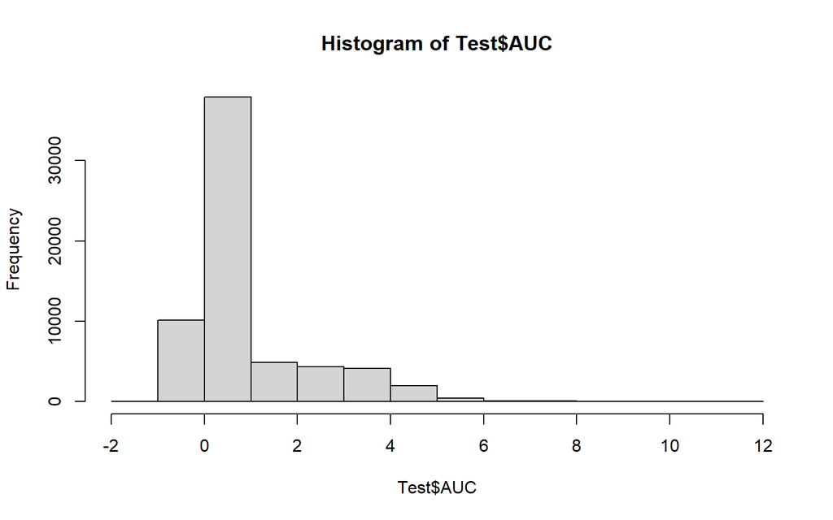

```r
Test$congruence_z <- scale(Test$congruence)
Test$racesex <- Test$code
hist(Test$AUC)
```

I also group mean centered “response” because it is actually a trial-level variable that is part of a cross-level interaction. A little weird to center because it’s a binary variable but necessary to isolate within-subject variance. The between-subject variance will not be included in the model, as it is not of interest.

```r
response_means <- aggregate(response_c ~ subject, data=Test, mean)
names(response_means)[2] <- "response_mean"
Test <- merge(Test, response_means, by.x='subject', by.y='subject', no.dups=TRUE)

Test$response_c_c <- Test$response_c - Test$response_mean
```

# Analyses

## Main model, AUC

```r
MainTest <- lmer(AUC ~ response_c*congruence_z + (1|subject) + (1|stimfile) + (1|racesex) + (response_c|subject:racesex), data=Test)
summ(MainTest, digits=3, confint=TRUE)
```

```
## If summ is taking too long to run, try setting r.squared = FALSE.
```

```
## MODEL INFO:
## Observations: 63869
## Dependent Variable: AUC
## Type: Mixed effects linear regression
##
## MODEL FIT:
## AIC = 204201.972, BIC = 204301.683
## Pseudo-R² (fixed effects) = 0.020
## Pseudo-R² (total) = 0.250
##
## FIXED EFFECTS:
## ------------------------------------------------------------------------------------
##                                   Est.     2.5%    97.5%   t val.       d.f.       p
## ----------------------------- -------- -------- -------- -------- ---------- -------
## (Intercept)                      1.003    0.950    1.057   36.797    145.897   0.000
## response_c                       0.166    0.137    0.195   11.101   1252.529   0.000
## congruence_z                    -0.007   -0.022    0.007   -0.991    694.516   0.322
## response_c:congruence_z         -0.099   -0.127   -0.070   -6.848   1413.941   0.000
## ------------------------------------------------------------------------------------
##
## p values calculated using Satterthwaite d.f.
##
## RANDOM EFFECTS:
## -------------------------------------------
##       Group         Parameter    Std. Dev.
## ----------------- ------------- -----------
##  subject:racesex   (Intercept)     0.153
##  subject:racesex   response_c      0.506
##      subject       (Intercept)     0.377
##     stimfile       (Intercept)     0.032
##      racesex       (Intercept)     0.016
##     Residual                       1.158
## -------------------------------------------
##
## Grouping variables:
## ------------------------------------
##       Group        # groups    ICC
## ----------------- ---------- -------
##  subject:racesex     1320     0.015
##      subject         220      0.094
##     stimfile         150      0.001
##      racesex          6       0.000
## ------------------------------------
```

## Main model, trait

Test for heterogeneity of interaction and main effects by trait. Important for generalizability of findings.

```r
TraitTest <- lmer(AUC ~ response_c*congruence_z*trait + (trait|subject) + (1|stimfile) + (1|racesex) + (response_c|subject:racesex), data=Test)
```

```
## boundary (singular) fit: see ?isSingular
```

```r
anova(TraitTest)
```

```
## Type III Analysis of Variance Table with Satterthwaite's method
##                               Sum Sq Mean Sq NumDF   DenDF F value    Pr(>F)
## response_c                    128.56 128.557     1 1281.21 95.9055 < 2.2e-16
## congruence_z                    3.12   3.119     1  741.81  2.3266   0.12761
## trait                          13.20   2.640     5   90.97  1.9693   0.09067
## response_c:congruence_z        69.25  69.252     1 1455.92 51.6631 1.049e-12
## response_c:trait              410.96  82.192     5 1458.14 61.3170 < 2.2e-16
## congruence_z:trait              8.32   1.664     5  535.92  1.2417   0.28817
## response_c:congruence_z:trait   8.01   1.602     5 1358.34  1.1950   0.30928
##
## response_c                    ***
## congruence_z
## trait                         .
## response_c:congruence_z       ***
## response_c:trait              ***
## congruence_z:trait
## response_c:congruence_z:trait
## ---
## Signif. codes:  0 '***' 0.001 '**' 0.01 '*' 0.05 '.' 0.1 ' ' 1
```

```r
summ(TraitTest, digits=3, confint=TRUE)
```

```
## MODEL INFO:
## Observations: 63869
## Dependent Variable: AUC
## Type: Mixed effects linear regression
##
## MODEL FIT:
## AIC = 204053.867, BIC = 204516.161
## Pseudo-R² (fixed effects) = 0.046
## Pseudo-R² (total) = 0.250
##
## FIXED EFFECTS:
## ---------------------------------------------------------------------------
##                                            Est.     2.5%    97.5%    t val.
## -------------------------------------- -------- -------- -------- ---------
## (Intercept)                               1.135    1.038    1.232    23.003
## response_c                                0.583    0.523    0.644    18.901
## congruence_z                             -0.046   -0.083   -0.009    -2.457
## traitDom                                 -0.198   -0.354   -0.043    -2.497
## traitFri                                 -0.114   -0.264    0.036    -1.489
## traitInt                                 -0.220   -0.380   -0.059    -2.680
## traitStr                                 -0.128   -0.279    0.023    -1.667
## traitTru                                 -0.147   -0.335    0.042    -1.524
## response_c:congruence_z                  -0.167   -0.230   -0.104    -5.166
## response_c:traitDom                      -0.370   -0.453   -0.287    -8.717
## response_c:traitFri                      -0.391   -0.479   -0.303    -8.687
## response_c:traitInt                      -0.636   -0.724   -0.547   -14.124
## response_c:traitStr                      -0.529   -0.618   -0.440   -11.689
## response_c:traitTru                      -0.740   -0.839   -0.641   -14.594
## congruence_z:traitDom                     0.059    0.010    0.107     2.376
## congruence_z:traitFri                     0.036   -0.015    0.088     1.379
## congruence_z:traitInt                     0.047   -0.004    0.098     1.790
## congruence_z:traitStr                     0.037   -0.010    0.085     1.537
## congruence_z:traitTru                     0.026   -0.036    0.087     0.820
## response_c:congruence_z:traitDom          0.080   -0.007    0.167     1.805
## response_c:congruence_z:traitFri          0.086   -0.008    0.181     1.793
## response_c:congruence_z:traitInt          0.074   -0.018    0.166     1.568
## response_c:congruence_z:traitStr          0.046   -0.039    0.130     1.060
## response_c:congruence_z:traitTru          0.106   -0.003    0.216     1.901
## ---------------------------------------------------------------------------
##
```

[output cut: 42 more lines]

```
##      subject        traitTru       0.711
##     stimfile       (Intercept)     0.033
##      racesex       (Intercept)     0.016
##     Residual                       1.158
## -------------------------------------------
##
## Grouping variables:
## ------------------------------------
##       Group        # groups    ICC
## ----------------- ---------- -------
##  subject:racesex     1320     0.014
##      subject         220      0.065
##     stimfile         150      0.001
##      racesex          6       0.000
## ------------------------------------
```

# Supplementary code for analyses of spatial entropy

```r
#standardize because it is a very small number, makes output hard to read in raw form
Test$Entropy_z <- scale(Test$x_SampEntropy)

MainTest_Entropy <- lmer(Entropy_z ~ response_c*congruence_z + (1|subject) + (1|stimfile) + (1|racesex) + (response_c|subject:racesex), data=Test)
summ(MainTest_Entropy, digits=3, confint=TRUE)
```

```
## MODEL INFO:
## Observations: 63869
## Dependent Variable: Entropy_z
## Type: Mixed effects linear regression
##
## MODEL FIT:
## AIC = 171861.833, BIC = 171961.544
## Pseudo-R² (fixed effects) = 0.004
## Pseudo-R² (total) = 0.184
##
## FIXED EFFECTS:
## ------------------------------------------------------------------------------------
##                                   Est.     2.5%    97.5%   t val.       d.f.       p
## ----------------------------- -------- -------- -------- -------- ---------- -------
## (Intercept)                      0.053    0.001    0.104    2.017    195.842   0.045
## response_c                       0.044    0.031    0.057    6.686   1223.505   0.000
## congruence_z                    -0.004   -0.014    0.006   -0.772    899.002   0.440
## response_c:congruence_z         -0.048   -0.061   -0.036   -7.506   1249.870   0.000
## ------------------------------------------------------------------------------------
##
## p values calculated using Satterthwaite d.f.
##
## RANDOM EFFECTS:
## -------------------------------------------
##       Group         Parameter    Std. Dev.
## ----------------- ------------- -----------
##  subject:racesex   (Intercept)     0.081
##  subject:racesex   response_c      0.188
##      subject       (Intercept)     0.376
##     stimfile       (Intercept)     0.016
##      racesex       (Intercept)     0.012
##     Residual                       0.910
## -------------------------------------------
##
## Grouping variables:
## ------------------------------------
##       Group        # groups    ICC
## ----------------- ---------- -------
##  subject:racesex     1320     0.007
##      subject         220      0.144
##     stimfile         150      0.000
##      racesex          6       0.000
## ------------------------------------
```

# Stereotype Knowledge

## Data preparation

Next, create a data frame to analyze race-by-gender patterns of stereotype knowledge, which is useful for more trait-specific interpretations of our main models.

```r
SterKnow <- data.frame(aggregate(cbind(BM_1, BM_2, BM_3, BM_4, BM_5, BM_6,
                                       AM_1, AM_2, AM_3, AM_4, AM_5, AM_6,
                                       WM_1, WM_2, WM_3, WM_4, WM_5, WM_6,
                                       BF_1, BF_2, BF_3, BF_4, BF_5, BF_6,
                                       AF_1, AF_2, AF_3, AF_4, AF_5, AF_6,
                                       WF_1, WF_2, WF_3, WF_4, WF_5, WF_6) ~ subject, data=Test, mean))



#wide to long, with some variable creation and adjustments
SterKnowLong <- gather(SterKnow, Condition, Rating, BM_1:WF_6)
SterKnowLong$trait <- substr(SterKnowLong$Condition, 4, 4)
SterKnowLong$racesex <- substr(SterKnowLong$Condition, 1, 2)
table(SterKnowLong$trait)
```

```
##
##    1    2    3    4    5    6
## 1320 1320 1320 1320 1320 1320
```

```r
SterKnowLong$trait <- recode(SterKnowLong$trait, "1" = "Att", "2" = "Dom", "3" = "Fri", "4" = "Int", "5" = "Str", "6" = "Tru")

#redefining race and sex
SterKnowLong$race <- ifelse(startsWith(SterKnowLong$racesex, "B"), "B",
                    ifelse(startsWith(SterKnowLong$racesex, "A"), "A", "W"))
table(SterKnowLong$race)
```

```
##
##    A    B    W
## 2640 2640 2640
```

```r
SterKnowLong$sex <- ifelse(endsWith(SterKnowLong$racesex, "F"), "F", "M")
table(SterKnowLong$sex)
```

```
##
##    F    M
## 3960 3960
```

```r
SterKnowLong$race <- as.factor(SterKnowLong$race)
SterKnowLong$sex <- as.factor(SterKnowLong$sex)

SterKnowLong$race <- fct_recode(SterKnowLong$race, `East Asian` = "A", Black = "B", White = "W")
SterKnowLong$sex <- fct_recode(SterKnowLong$sex, Women = "F", Men = "M")

SterKnowLong$congruence <- SterKnowLong$Rating
```

## Graphs

```r
#estimate Stereotype Knowledge by race and sex

#Attractive

AttSK <- lmer(congruence ~ race*sex + (1|subject), data=subset(SterKnowLong, trait=="Att"))
anova(AttSK)
```

```
## Type III Analysis of Variance Table with Satterthwaite's method
##          Sum Sq Mean Sq NumDF DenDF F value    Pr(>F)
## race     900.48  450.24     2  1095 424.218 < 2.2e-16 ***
## sex       50.82   50.82     1  1095  47.882  7.69e-12 ***
## race:sex 132.37   66.18     2  1095  62.360 < 2.2e-16 ***
## ---
## Signif. codes:  0 '***' 0.001 '**' 0.01 '*' 0.05 '.' 0.1 ' ' 1
```

```r
summ(AttSK)
```

```
## MODEL INFO:
## Observations: 1320
## Dependent Variable: congruence
## Type: Mixed effects linear regression
##
## MODEL FIT:
## AIC = 4046.37, BIC = 4087.86
## Pseudo-R² (fixed effects) = 0.39
## Pseudo-R² (total) = 0.50
##
## FIXED EFFECTS:
## ---------------------------------------------------------------
##                           Est.   S.E.   t val.      d.f.      p
## ---------------------- ------- ------ -------- --------- ------
## (Intercept)               4.69   0.08    60.85   1116.49   0.00
## raceBlack                -0.32   0.10    -3.29   1095.00   0.00
## raceWhite                 1.45   0.10    14.81   1095.00   0.00
## sexMen                   -1.22   0.10   -12.45   1095.00   0.00
## raceBlack:sexMen          1.54   0.14    11.06   1095.00   0.00
## raceWhite:sexMen          0.95   0.14     6.87   1095.00   0.00
## ---------------------------------------------------------------
##
## p values calculated using Satterthwaite d.f.
##
## RANDOM EFFECTS:
## ------------------------------------
##   Group      Parameter    Std. Dev.
## ---------- ------------- -----------
##  subject    (Intercept)     0.50
##  Residual                   1.03
## ------------------------------------
##
## Grouping variables:
## ---------------------------
##   Group    # groups   ICC
## --------- ---------- ------
##  subject     220      0.19
## ---------------------------
```

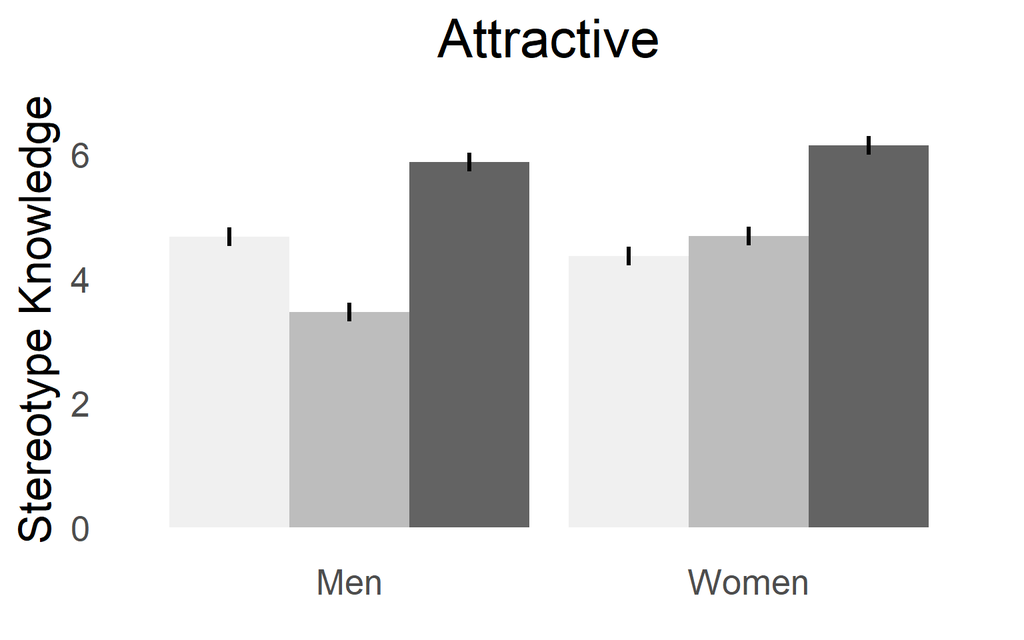

```r
AttSK_EM <- emmeans(AttSK, ~ race | sex)

AttSK_EM_tidy <- tidy(AttSK_EM, conf.int = TRUE, conf.level = .95)

AttSK_plot <- ggplot(data=AttSK_EM_tidy, aes(x=sex, y=estimate, fill=race)) +
  geom_bar(stat="identity", position=position_dodge())+
  geom_errorbar(aes(ymin=conf.low, ymax=conf.high), colour = "black", width=0, size = 1.2,
                position=position_dodge(.9)) +
  ggtitle("Attractive") +
  ylab("Stereotype Knowledge") +
  xlab(element_blank()) +
  scale_y_continuous(limits=c(0,6.7)) +
  scale_fill_brewer(palette = "Greys") +
  theme_minimal(base_size=25) +
  theme(legend.position = "none") +
  theme(plot.title = element_text(hjust = 0.5)) +
  theme(panel.grid.major = element_blank(), panel.grid.minor = element_blank()) +
  theme(plot.margin=margin(10,20,10,10))

AttSK_plot
```

```r
#Dominance

DomSK <- lm(congruence ~ race*sex, data=subset(SterKnowLong, trait=="Dom"))
summ(DomSK)
```

```
## MODEL INFO:
## Observations: 1320
## Dependent Variable: congruence
## Type: OLS linear regression
##
## MODEL FIT:
## F(5,1314) = 213.26, p = 0.00
## R² = 0.45
## Adj. R² = 0.45
##
## Standard errors: OLS
## ----------------------------------------------------
##                          Est.   S.E.   t val.      p
## ---------------------- ------ ------ -------- ------
## (Intercept)              2.78   0.09    31.39   0.00
## raceBlack                2.11   0.13    16.86   0.00
## raceWhite                1.03   0.13     8.23   0.00
## sexMen                   0.42   0.13     3.34   0.00
## raceBlack:sexMen         0.36   0.18     2.05   0.04
## raceWhite:sexMen         1.62   0.18     9.13   0.00
## ----------------------------------------------------
```

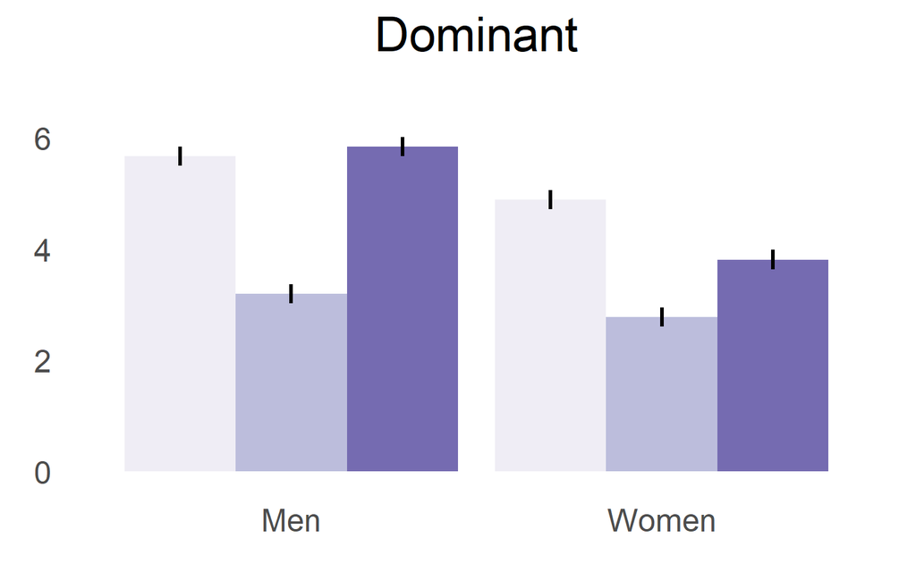

```r
DomSK_EM <- emmeans(DomSK, ~ race | sex)

DomSK_EM_tidy <- tidy(DomSK_EM, conf.int = TRUE, conf.level = .95)

DomSK_plot <- ggplot(data=DomSK_EM_tidy, aes(x=sex, y=estimate, fill=race)) +
  geom_bar(stat="identity", position=position_dodge())+
  geom_errorbar(aes(ymin=conf.low, ymax=conf.high), colour = "black", width=0, size = 1.2,
                position=position_dodge(.9)) +
  ggtitle("Dominant") +
  ylab(element_blank()) +
  xlab(element_blank()) +
  scale_y_continuous(limits=c(0,6.7)) +
  scale_fill_brewer(palette = "Purples") +
  theme_minimal(base_size=25) +
  theme(legend.position = "none") +
  theme(plot.title = element_text(hjust = 0.5)) +
  theme(panel.grid.major = element_blank(), panel.grid.minor = element_blank()) +
  theme(plot.margin=margin(10,20,10,10))

DomSK_plot
```

```r
#Friendly

FriSK <- lm(congruence ~ race*sex, data=subset(SterKnowLong, trait=="Fri"))
anova(FriSK)
```

```
## Analysis of Variance Table
##
## Response: congruence
##             Df  Sum Sq Mean Sq  F value    Pr(>F)
## race         2  333.86 166.930 108.7525 < 2.2e-16 ***
## sex          1   39.73  39.728  25.8822 4.155e-07 ***
## race:sex     2    9.64   4.821   3.1409   0.04357 *
## Residuals 1314 2016.93   1.535
## ---
## Signif. codes:  0 '***' 0.001 '**' 0.01 '*' 0.05 '.' 0.1 ' ' 1
```

```r
summ(FriSK)
```

```
## MODEL INFO:
## Observations: 1320
## Dependent Variable: congruence
## Type: OLS linear regression
##
## MODEL FIT:
## F(5,1314) = 49.93, p = 0.00
## R² = 0.16
## Adj. R² = 0.16
##
## Standard errors: OLS
## -----------------------------------------------------
##                           Est.   S.E.   t val.      p
## ---------------------- ------- ------ -------- ------
## (Intercept)               4.69   0.08    56.10   0.00
## raceBlack                -0.56   0.12    -4.77   0.00
## raceWhite                 0.81   0.12     6.85   0.00
## sexMen                   -0.17   0.12    -1.42   0.15
## raceBlack:sexMen         -0.13   0.17    -0.76   0.45
## raceWhite:sexMen         -0.41   0.17    -2.45   0.01
## -----------------------------------------------------
```

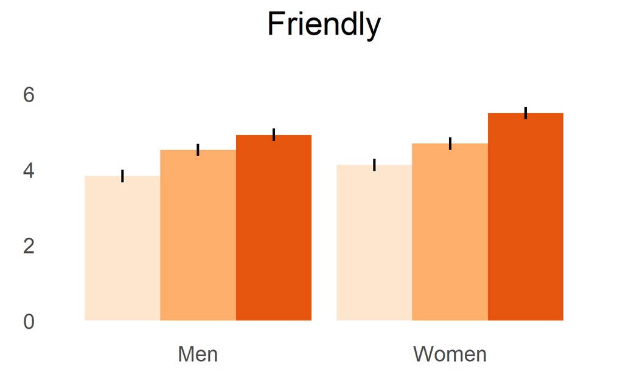

```r
FriSK_EM <- emmeans(FriSK, ~ race | sex)

FriSK_EM_tidy <- tidy(FriSK_EM, conf.int = TRUE, conf.level = .95)

FriSK_plot <- ggplot(data=FriSK_EM_tidy, aes(x=sex, y=estimate, fill=race)) +
  geom_bar(stat="identity", position=position_dodge())+
  geom_errorbar(aes(ymin=conf.low, ymax=conf.high), colour = "black", width=0, size = 1.2,
                position=position_dodge(.9)) +
  ggtitle("Friendly") +
  ylab(element_blank()) +
  xlab(element_blank()) +
  scale_y_continuous(limits=c(0,6.7)) +
  scale_fill_brewer(palette = "Oranges") +
  theme_minimal(base_size=25) +
  theme(legend.position = "none") +
  theme(plot.title = element_text(hjust = 0.5)) +
  theme(panel.grid.major = element_blank(), panel.grid.minor = element_blank()) +
  theme(plot.margin=margin(10,20,10,10))

FriSK_plot
```

```r
#Intelligent

IntSK <- lm(congruence ~ race*sex, data=subset(SterKnowLong, trait=="Int"))
anova(IntSK)
```

```
## Analysis of Variance Table
##
## Response: congruence
##             Df  Sum Sq Mean Sq F value    Pr(>F)
## race         2 1451.87  725.94 582.656 < 2.2e-16 ***
## sex          1   50.43   50.43  40.474 2.745e-10 ***
## race:sex     2   46.56   23.28  18.685 9.967e-09 ***
## Residuals 1314 1637.13    1.25
## ---
## Signif. codes:  0 '***' 0.001 '**' 0.01 '*' 0.05 '.' 0.1 ' ' 1
```

```r
summ(IntSK)
```

```
## MODEL INFO:
## Observations: 1320
## Dependent Variable: congruence
## Type: OLS linear regression
##
## MODEL FIT:
## F(5,1314) = 248.63, p = 0.00
## R² = 0.49
## Adj. R² = 0.48
##
## Standard errors: OLS
## -----------------------------------------------------
##                           Est.   S.E.   t val.      p
## ---------------------- ------- ------ -------- ------
## (Intercept)               6.01   0.08    79.91   0.00
## raceBlack                -2.28   0.11   -21.40   0.00
## raceWhite                -1.34   0.11   -12.60   0.00
## sexMen                    0.47   0.11     4.44   0.00
## raceBlack:sexMen         -0.58   0.15    -3.84   0.00
## raceWhite:sexMen          0.33   0.15     2.20   0.03
## -----------------------------------------------------
```

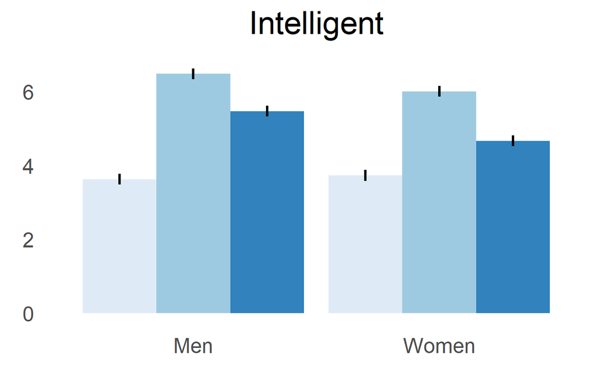

```r
IntSK_EM <- emmeans(IntSK, ~ race | sex)

IntSK_EM_tidy <- tidy(IntSK_EM, conf.int = TRUE, conf.level = .95)

IntSK_plot <- ggplot(data=IntSK_EM_tidy, aes(x=sex, y=estimate, fill=race)) +
  geom_bar(stat="identity", position=position_dodge())+
  geom_errorbar(aes(ymin=conf.low, ymax=conf.high), colour = "black", width=0, size = 1.2,
                position=position_dodge(.9)) +
  ggtitle("Intelligent") +
  ylab(element_blank()) +
  xlab(element_blank()) +
  scale_y_continuous(limits=c(0,6.7)) +
  scale_fill_brewer(palette = "Blues") +
  theme_minimal(base_size=25) +
  theme(legend.position = "none") +
  theme(plot.title = element_text(hjust = 0.5)) +
  theme(panel.grid.major = element_blank(), panel.grid.minor = element_blank()) +
  theme(plot.margin=margin(10,20,10,10))

IntSK_plot
```

```r
#Physically strong

StrSK <- lm(congruence ~ race*sex, data=subset(SterKnowLong, trait=="Str"))
anova(StrSK)
```

```
## Analysis of Variance Table
##
## Response: congruence
##             Df  Sum Sq Mean Sq F value    Pr(>F)
## race         2 2029.94 1014.97  841.40 < 2.2e-16 ***
## sex          1  724.61  724.61  600.70 < 2.2e-16 ***
## race:sex     2  121.79   60.89   50.48 < 2.2e-16 ***
## Residuals 1314 1585.05    1.21
## ---
## Signif. codes:  0 '***' 0.001 '**' 0.01 '*' 0.05 '.' 0.1 ' ' 1
```

```r
summ(StrSK)
```

```
## MODEL INFO:
## Observations: 1320
## Dependent Variable: congruence
## Type: OLS linear regression
##
## MODEL FIT:
## F(5,1314) = 476.89, p = 0.00
## R² = 0.64
## Adj. R² = 0.64
##
## Standard errors: OLS
## ----------------------------------------------------
##                          Est.   S.E.   t val.      p
## ---------------------- ------ ------ -------- ------
## (Intercept)              2.32   0.07    31.31   0.00
## raceBlack                2.70   0.10    25.74   0.00
## raceWhite                0.85   0.10     8.12   0.00
## sexMen                   0.76   0.10     7.25   0.00
## raceBlack:sexMen         0.68   0.15     4.60   0.00
## raceWhite:sexMen         1.49   0.15    10.04   0.00
## ----------------------------------------------------
```

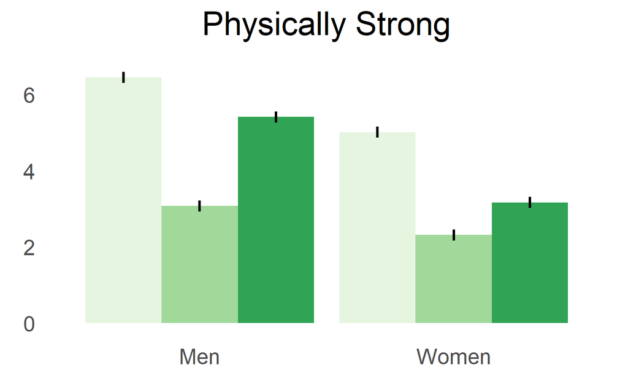

```r
StrSK_EM <- emmeans(StrSK, ~ race | sex)

StrSK_EM_tidy <- tidy(StrSK_EM, conf.int = TRUE, conf.level = .95)

StrSK_plot <- ggplot(data=StrSK_EM_tidy, aes(x=sex, y=estimate, fill=race)) +
  geom_bar(stat="identity", position=position_dodge())+
  geom_errorbar(aes(ymin=conf.low, ymax=conf.high), colour = "black", width=0, size = 1.2,
                position=position_dodge(.9)) +
  ggtitle("Physically Strong") +
  ylab(element_blank()) +
  xlab(element_blank()) +
  scale_y_continuous(limits=c(0,6.7)) +
  scale_fill_brewer(palette = "Greens") +
  theme_minimal(base_size=25) +
  theme(legend.position = "none") +
  theme(plot.title = element_text(hjust = 0.5)) +
  theme(panel.grid.major = element_blank(), panel.grid.minor = element_blank()) +
  theme(plot.margin=margin(10,20,10,10))

StrSK_plot
```

```r
#Trustworthy

TruSK <- lm(congruence ~ race*sex, data=subset(SterKnowLong, trait=="Tru"))
anova(TruSK)
```

```
## Analysis of Variance Table
##
## Response: congruence
##             Df  Sum Sq Mean Sq  F value    Pr(>F)
## race         2  496.10 248.051 158.8490 < 2.2e-16 ***
## sex          1   59.82  59.819  38.3074 8.061e-10 ***
## race:sex     2   16.80   8.401   5.3798  0.004711 **
## Residuals 1314 2051.88   1.562
## ---
## Signif. codes:  0 '***' 0.001 '**' 0.01 '*' 0.05 '.' 0.1 ' ' 1
```

```r
summ(TruSK)
```

```
## MODEL INFO:
## Observations: 1320
## Dependent Variable: congruence
## Type: OLS linear regression
##
## MODEL FIT:
## F(5,1314) = 73.35, p = 0.00
## R² = 0.22
## Adj. R² = 0.22
##
## Standard errors: OLS
## -----------------------------------------------------
##                           Est.   S.E.   t val.      p
## ---------------------- ------- ------ -------- ------
## (Intercept)               4.80   0.08    57.03   0.00
## raceBlack                -0.85   0.12    -7.13   0.00
## raceWhite                 0.48   0.12     4.01   0.00
## sexMen                   -0.13   0.12    -1.07   0.29
## raceBlack:sexMen         -0.55   0.17    -3.24   0.00
## raceWhite:sexMen         -0.35   0.17    -2.08   0.04
## -----------------------------------------------------
```

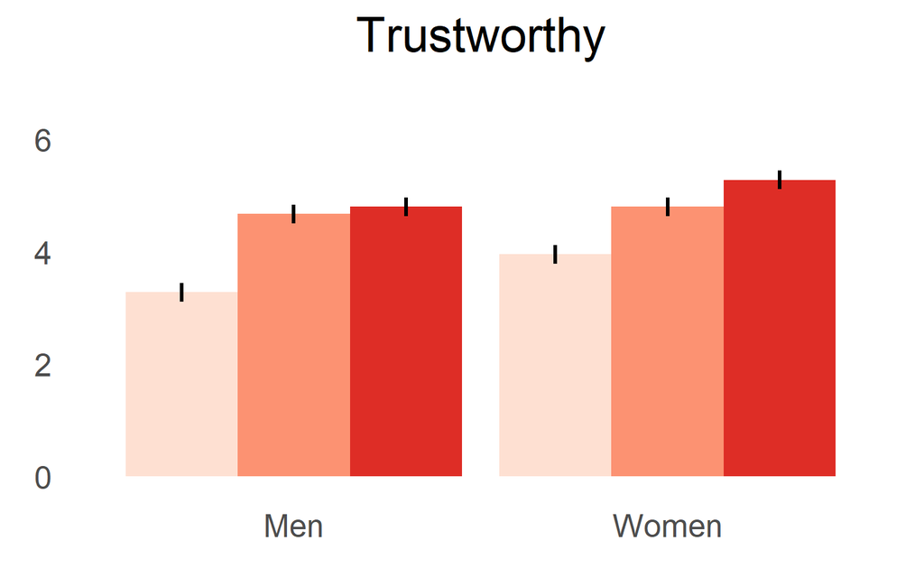

```r
TruSK_EM <- emmeans(TruSK, ~ race | sex)

TruSK_EM_tidy <- tidy(TruSK_EM, conf.int = TRUE, conf.level = .95)

TruSK_plot <- ggplot(data=TruSK_EM_tidy, aes(x=sex, y=estimate, fill=race)) +
  geom_bar(stat="identity", position=position_dodge())+
  geom_errorbar(aes(ymin=conf.low, ymax=conf.high), colour = "black", width=0, size = 1.2,
                position=position_dodge(.9)) +
  ggtitle("Trustworthy") +
  ylab(element_blank()) +
  xlab(element_blank()) +
  scale_y_continuous(limits=c(0,6.7)) +
  scale_fill_brewer(palette = "Reds") +
  theme_minimal(base_size=25) +
  theme(legend.position = "none") +
  theme(plot.title = element_text(hjust = 0.5)) +
  theme(panel.grid.major = element_blank(), panel.grid.minor = element_blank()) +
  theme(plot.margin=margin(10,20,10,10))

TruSK_plot
```

```r
#commented out lines used to save large .tif file for publications

#SK_plot <- (AttSK_plot | DomSK_plot | FriSK_plot) / (IntSK_plot | StrSK_plot | TruSK_plot)

#dpi=300
#tiff("figures/SK_all.tif", width=12*dpi, height=8*dpi, res=dpi)

#SK_plot

#dev.off()
```

# Plotting

NOTE: Due to an R, mousetrap, or ggplot update, the background trajectories may not graph properly

## Data preparation

For plotting the full trajectories, must convert data to a mousetrap object.

For graphing, I do a little data management prior to converting to mousetrap object.

```r
#this is the closet division of top and bottom tertiles possible given the integer nature of the congruence scores

Test$Congruency <- ifelse(Test$congruence<=3, "low",
                           ifelse(Test$congruence>=6, "high", NA))
table(Test$Congruency)
```

```
##
##  high   low
## 22225 14491
```

```r
#this version of response is used for graphing purposes. the group mean centered version of response will not be graphed, as this is difficult to do.

Test$response_text <- ifelse(Test$response_c==-1, "Categorized as 'Less ______'", "Categorized as 'More ______'")

#this removes the middle tertile of responses, which we will not graph.
Test_graph <- subset(Test, is.na(Test$Congruency)==FALSE)

#create first mousetrap object. Warning messages are fine, it's just saying that a timestamp variable was not explicitly defined.
mt_data <- mt_import_wide(Test_graph)
```

```
## No mt_id_label provided. A new trial identifying variable called mt_id was created.
```

```
## No pos_ids provided. The following variables were found using grep:
```

```
## 101 variables found for xpos.
```

```
## 101 variables found for ypos.
```

```
## 0 variables found for timestamps. Artificial timestamps variable created assuming equidistant time steps.
```

## Creating graphs

It’s pretty intense due to the individual trajectories, which is why output is not printed here (see paper).

```r
dpi <- 300

#graph individual_traj for the purpose of creating the dataset within the ggplot object
individual_traj <- mt_plot(mt_data, points = FALSE, x = "xpos", y = "ypos", facet_col = "response_text", only_ggplot=TRUE) +
  geom_path(color="gray", alpha = .01) +
  theme_minimal()

#create the agg_traj object, which contains most of the stylistic and thematic info
agg_traj <- mt_plot_aggregate(mt_data, points = TRUE, x = "xpos", y = "ypos", color="Congruency", facet_col="response_text", only_ggplot=TRUE, subject_id="subject") +
  geom_path(alpha=1) +
  geom_point(alpha=1) +
  #geom_hline(data=segment_low, aes(yintercept=ypos), linetype="dashed") +
  #geom_hline(data=segment_high, aes(yintercept=ypos), linetype="dashed") +
  theme_minimal() +
  xlab("x-coordinates") +
  ylab("y-coordinates") +
  labs(color = "Stereotype-Expectancy") +
  theme(panel.grid.major.x = element_blank(),
        panel.grid.minor.x = element_blank(),
        panel.grid.major.y = element_blank(),
        panel.grid.minor.y = element_blank(),
        legend.position = c(.5, .27),
        legend.text = element_text(size=12),
        legend.title = element_text(size=13),
        strip.text = element_text(size=15),
        axis.title.x = element_text(size=16),
        axis.title.y = element_text(size=16),
        plot.title = element_text(hjust = .5, size=17)) +
  scale_y_continuous(breaks=c(0, .5, 1., 1.5), limits=c(0, 1.5)) +
  scale_x_continuous(breaks=c(-1, -.5, 0, .5, 1), limits=c(-1, 1)) +
  scale_colour_manual(values=c("#DC3220", "#005AB5")) +
  ggtitle("Time-Normalized Trajectories by Stereotype-Expectancy and Response")

#combine agg_traj with a geom_path drawn using the individual_traj dataset
total_traj <- agg_traj + geom_path(data=individual_traj$data, color="gray", alpha = .01)

tiff("figures/xy.tif", width=12*dpi, height=6*dpi, res=dpi)

total_traj

dev.off()
```

```r
total_traj_v2 <- mt_plot_aggregate(mt_data, points = TRUE, x = "xpos", y = "ypos", color="Congruency", facet_col="response_text", only_ggplot=TRUE, subject_id="subject") +
  geom_path(data=sample_n(individual_traj$data, 1000000), color="darkgray", alpha = .01) +
  geom_path(alpha=1) +
  geom_point(alpha=1) +
  #geom_hline(data=segment_low, aes(yintercept=ypos), linetype="dashed") +
  #geom_hline(data=segment_high, aes(yintercept=ypos), linetype="dashed") +
  theme_minimal() +
  xlab("x-coordinates") +
  ylab("y-coordinates") +
  labs(color = "Stereotype-Expectancy") +
  theme(panel.grid.major.x = element_blank(),
        panel.grid.minor.x = element_blank(),
        panel.grid.major.y = element_blank(),
        panel.grid.minor.y = element_blank(),
        legend.position = c(.5, .27),
        legend.text = element_text(size=12),
        legend.title = element_text(size=13),
        strip.text = element_text(size=15),
        axis.title.x = element_text(size=16),
        axis.title.y = element_text(size=16),
        plot.title = element_text(hjust = .5, size=17)) +
  scale_y_continuous(breaks=c(0, .5, 1., 1.5), limits=c(0, 1.5)) +
  scale_x_continuous(breaks=c(-1, -.5, 0, .5, 1), limits=c(-1, 1)) +
  scale_colour_manual(values=c("#DC3220", "#005AB5")) +
  ggtitle("Time-Normalized Trajectories by Stereotype-Expectancy and Response")

tiff("figures/xy_v2.tif", width=12*dpi, height=6*dpi, res=dpi)

total_traj_v2

dev.off()
```

## Graphs by trait

```r
mt_data$data$trait <- fct_recode(as.factor(mt_data$data$trait), Attractive = "Att", Dominant = "Dom",
                                           Friendly = "Fri", Intelligent = "Int",
                                           `Physically Strong` = "Str", Trustworthy = "Tru")

#graph individual_traj for the purpose of creating the dataset within the ggplot object
individual_traj_trait <- mt_plot(mt_data, points = FALSE, x = "xpos", y = "ypos", color="Congruency", facet_col = "response_text", facet_row = "trait", only_ggplot=TRUE) +
  geom_path(color="gray", alpha = .006) +
  theme_minimal()

#create the agg_traj object, which contains most of the stylistic and thematic info
agg_traj_trait <- mt_plot_aggregate(mt_data, points = TRUE, x = "xpos", y = "ypos", color="Congruency", facet_col="response_text", facet_row = "trait", only_ggplot=TRUE, subject_id="subject") +
  geom_path(alpha=1) +
  geom_point(alpha=1) +
  #geom_hline(data=segment_low, aes(yintercept=ypos), linetype="dashed") +
  #geom_hline(data=segment_high, aes(yintercept=ypos), linetype="dashed") +
  theme_minimal() +
  xlab("x-coordinates") +
  ylab("y-coordinates") +
  labs(color = "Stereotype-Expectancy") +
  theme(panel.grid.major.x = element_blank(),
        panel.grid.minor.x = element_blank(),
        panel.grid.major.y = element_blank(),
        panel.grid.minor.y = element_blank(),
        #legend.position = c(.5, .27),
        legend.text = element_text(size=12),
        legend.title = element_text(size=13),
        strip.text = element_text(size=15),
        axis.title.x = element_text(size=16),
        axis.title.y = element_text(size=16),
        plot.title = element_text(hjust = .5, size=17)) +
  scale_y_continuous(breaks=c(0, .5, 1., 1.5), limits=c(0, 1.5)) +
  scale_x_continuous(breaks=c(-1, -.5, 0, .5, 1), limits=c(-1, 1)) +
  scale_colour_manual(values=c("#DC3220", "#005AB5")) +
  ggtitle("Time-Normalized Trajectories by Stereotype-Expectancy and Response, by Trait")

#combine agg_traj with a geom_path drawn using the individual_traj dataset
total_traj_trait <- agg_traj_trait + geom_path(data=individual_traj_trait$data, color="gray", alpha = .006)

tiff("figures/xy_trait.tif", width=14*dpi, height=15*dpi, res=dpi)

total_traj_trait

dev.off()
```